# Predykcja cen akcji spółki PZU oraz korelacja z czynnikimi gospodarczymi

Analiza i prognozowanie wielowymiarowego szeregu czasowego

Autorzy

Afiliacje

Maciej Kuchcik

Andrzej Szuwald

Uniwersytet Ekonomiczny w Katowicach

Analiza zjawisk dynamicznych

DATA

19 czerwca 2026

# Inicjalizacja

W tej części ładowane są biblioteki oraz inicjalizowane są zmienne.

Zmienna $FORMAT$ jest flagą, która wskazuje jaki silnik został wykorzystany podczas renderowania. Wykorzystane jest to podczas tworzenia wykresów. Język R wtedy decyduje, czy wyrenderować wersję internetową (HTML: grafy interaktywne, zmieniające kolor w zależności od motywu), lub dokumentową (PDF: stałe zdjęcia).

**Import bibliotek**

```r
if (!require("quantmod")) install.packages("quantmod")
library(quantmod)
library(ggplot2)
if (!require("readxl")) install.packages("readxl")
library(readxl)
if (!require("tseries")) install.packages("tseries")
library(tseries)
if (!require("highcharter")) install.packages("highcharter")
library("highcharter")
if (!require("forecast")) install.packages("forecast")
library(forecast)
#if (!require("midasr")) install.packages("midasr")
#library(midasr)
if (!require("vars")) install.packages("vars")
library(vars)

options(highcharter.lang = list(
    months = c("Styczeń", "Luty", "Marzec", "Kwiecień", "Maj", "Czerwiec",
               "Lipiec", "Sierpień", "Wrzesień", "Październik",
               "Listopad", "Grudzień"),
    shortMonths = c("Sty", "Lut", "Mar", "Kwi", "Maj", "Cze",
                    "Lip", "Sie", "Wrz", "Paź", "Lis", "Gru"),
    weekdays = c("Niedziela", "Poniedziałek", "Wtorek", "Środa", "Czwartek",
                 "Piątek", "Sobota"),
    shortWeekdays = c("Nie", "Pon", "Wto", "Śro", "Czw", "Pią", "Sob"),
    rangeSelectorFrom = "Od",
    rangeSelectorTo = "Do",
    rangeSelectorZoom = "Zakres",
    loading = "Ładowanie..."
  )
)

FORMAT<-knitr::pandoc_to()
if (is.null(FORMAT)) {
  FORMAT <- "html"
}
```

**Funkcja ‘rysuj_rdzen’**

```r
# Autor: Maciej Kuchcik

rysuj_rdzen <- function(dane_ts, tytul, etykieta_y, kolory) {
  plot(dane_ts, xlab = "Rok", ylab = etykieta_y,
       main = tytul, col = kolory$linia, lwd = 2)
  grid(col = kolory$siatka)

  start_zagrozenia <- 2020 + (3 - 1) / 12
  koniec_zagrozenia <- 2023 + (6 - 1) / 12

  rect(start_zagrozenia, par("usr")[3], koniec_zagrozenia, par("usr")[4],
       col = rgb(1, 0, 0, 0.12), border = NA)

  legend("topleft", legend = "COVID", fill = rgb(1, 0, 0, 0.12),
         border = NA, bty = "n")
}

rysuj_makro_wykres <- function(dane_ts, tytul, etykieta_y, format = "pdf") {
  # Zawsze: jasna
  jasne_kolory <- list(linia = "royalblue", siatka = "#cccccc")
  par(bg = "white", col.axis = "black", col.lab = "black",
      col.main = "black", fg = "black")
  rysuj_rdzen(dane_ts, ifelse(format == "html", tytul, ""),

              etykieta_y, jasne_kolory)

  # HTML: rysujemy też wersję ciemną
  if (format == "html") {
    par(bg = "#222222", col.axis = "#dddddd", col.lab = "#dddddd",
        col.main = "#dddddd", fg = "#dddddd")
    ciemne_kolory <- list(linia = "#6baed6", siatka = "#444444")
    rysuj_rdzen(dane_ts, tytul, etykieta_y, ciemne_kolory)

    # Reset po HTML
    par(bg = "white", col.axis = "black", col.lab = "black",
        col.main = "black", fg = "black")
  }
}
```

**Funkcja ‘wykres_predykcji’**

```r
# Autor: Maciej Kuchcik

wykres_predykcji <- function(daty, cena_real, cena_pred, blad,
                              tytul, nazwa_modelu, format = FORMAT) {
  if (format == "html") {
    df <- data.frame(
      x           = as.numeric(as.POSIXct(daty)) * 1000,
      rzeczywiste = cena_real,
      prognoza    = cena_pred,
      blad        = blad
    )
    highchart() |>
      hc_title(text = tytul) |>
      hc_xAxis(type = "datetime") |>
      hc_yAxis_multiples(
        list(title = list(text = "Cena zamknięcia (zł)"), opposite = FALSE),
        list(title = list(text = "Błąd (zł)"), opposite = TRUE, gridLineWidth = 0)
      ) |>
      hc_add_series(
        data = list_parse2(data.frame(x = df$x, y = df$rzeczywiste)),
        type = "line", name = "Rzeczywista", color = "#2196F3", yAxis = 0
      ) |>
      hc_add_series(
        data = list_parse2(data.frame(x = df$x, y = df$prognoza)),
        type = "line", name = paste0("Prognoza ", nazwa_modelu),
        color = "#FF9800", dashStyle = "ShortDash", yAxis = 0
      ) |>
      hc_add_series(
        data = list_parse2(data.frame(x = df$x, y = df$blad)),
        type = "line", name = "Błąd", color = "rgba(229,57,53,0.5)", yAxis = 1
      ) |>
      hc_tooltip(valueDecimals = 2, valueSuffix = " zł", shared = TRUE) |>
      hc_legend(enabled = TRUE) |>
      hc_rangeSelector(enabled = TRUE) |>
      hc_scrollbar(enabled = TRUE)
  } else {
    par(bg = "white", col.axis = "black", col.lab = "black",
        col.main = "black", fg = "black")
    plot(daty, cena_real, type = "l", col = "royalblue", lwd = 1.5,
         xlab = "Data", ylab = "Cena zamknięcia (zł)", main = tytul)
    lines(daty, cena_pred, col = "tomato", lwd = 1.5, lty = 2)
    grid(col = "#cccccc")
    par(new = TRUE)
    plot(daty, blad, type = "l", col = adjustcolor("red3", alpha.f = 0.4),
         lwd = 1, axes = FALSE, xlab = "", ylab = "")
    axis(4, col = "red3", col.axis = "red3")
    mtext("Błąd (zł)", side = 4, line = 3, col = "red3")
    legend("topleft",
           legend = c("Rzeczywista", paste0("Prognoza ", nazwa_modelu), "Błąd"),
           col = c("royalblue", "tomato", "red3"),
           lty = c(1, 2, 1), lwd = 2, bty = "n")
  }
}
```

**Funkcja ‘oblicz_metryki’**

```r
# Autor: Maciej Kuchcik

oblicz_metryki <- function(blad, cena_real) {
  c(
    MAE  = mean(abs(blad)),
    RMSE = sqrt(mean(blad^2)),
    MAPE = mean(abs(blad / cena_real)) * 100
  )
}
```

**Funkcja ‘prognoza_var_rekursywna’**

```r
# Autor: Maciej Kuchcik

prognoza_var_rekursywna <- function(historia_df, test_xts, p_opt) {
  n <- nrow(test_xts)
  prognozy <- numeric(n)
  for (i in seq_len(n)) {
    dodatkowe <- if (i > 1) as.data.frame(test_xts)[seq_len(i - 1), , drop = FALSE] else NULL
    okno <- rbind(historia_df, dodatkowe)
    model_tmp <- VAR(okno, p = p_opt, type = "const")
    pred <- predict(model_tmp, n.ahead = 1)
    prognozy[i] <- pred$fcst$zamkniecia[1, "fcst"]
  }
  prognozy
}
```

**Funkcja ‘estymuj_var’**

```r
# Autor: Maciej Kuchcik

estymuj_var <- function(dane, lag.max = 10) {
  p_opt <- as.integer(VARselect(dane, lag.max = lag.max, type = "const")$selection["AIC(n)"])
  cat("Optymalny rząd VAR (AIC):", p_opt, "\n")
  list(
    model = VAR(dane, p = p_opt, type = "const"),
    p_opt = p_opt
  )
}
```

# Wstęp

## Cel

W tym projekcie porównamy różne metody predykcji akcji giełdowych spółki **PZU** (Powszechny Zakład Ubezpieczeń S.A.) oraz zbadamy wpływ dodania innych zmiennych na jakość danych wyjściowych.

Badanie rozpocznie się od stworzenia modelu naiwnego (bazowego), do którego porównywać się będą inne metryki. Model ten będzie zakładał, że
$$\text{predykowana cena} = \text{cena wczorajsza}$$
Następnie zostana wykorzystane bardziej złożone funkcje jak $VAR$ czy $ARIMAX$ (*przez autoarime*), do których później dodatkowo zostaną dołożone kolejne wymiary (np. dane o inflacji, stopie bezrobocia czy PKB) aby zweryfikować wpływ danych makroekonomicznych.

## Dane

Dane giełdowe pobrane zostaną pobrane z biblioteki **quantmod** poprzez API Yahoo Finance do GPW (Giełdy Papierów Wartościowych).

### Giełda PZU

**Pobranie danych giełdowych**

```r
# Autor: Maciej Kuchcik

pzu_raw<-getSymbols("PZU.WA", auto.assign = F)
```

**Pobranie danych giełdowych**

```r
if(FORMAT == "html"){
  p <- highchart(type = "stock")
  p <- hc_title(p, text = "Wykres akcji spółki PZU")
  p <- hc_add_series(p, pzu_raw, name = "Cena")
  p <- hc_navigator(p, enabled = TRUE)
  p <- hc_scrollbar(p, enabled = TRUE)

  p <- hc_yAxis(p,
    min = 0,
    max = max(Cl(pzu_raw))
  )

  p
}else{
  chartSeries(pzu_raw,
    theme = chartTheme("white"), name = "")
}
```

[interactive chart not shown]

### Wskaźniki makroekonomiczne

Wskaźniki makroekonomiczne zostały pobrane ze strony **GUS** (Główny Urząd Statystyczny) i pliku **Kwartalne wskaźniki makroekonomiczne** lub **Wybrane miesięczne wskaźniki makroekonomiczne** .

- PKB pobrano z danych kwartalnych z arkusza **RACHUNKI NARODOWE**.
- Inflacje pobrano z danych miesięcznych z arkusza **WSKAŹNIKI CEN**.
- Procentową stopę bezrobocia pobrano z danych miesięcznych z arkusza **RYNEK PRACY**.

Te dane zostały następnie przerobione ręcznie do pliku **makro.xlsx** do arkuszy o odpowiednich nazwach.

**Pobranie danych o PKB**

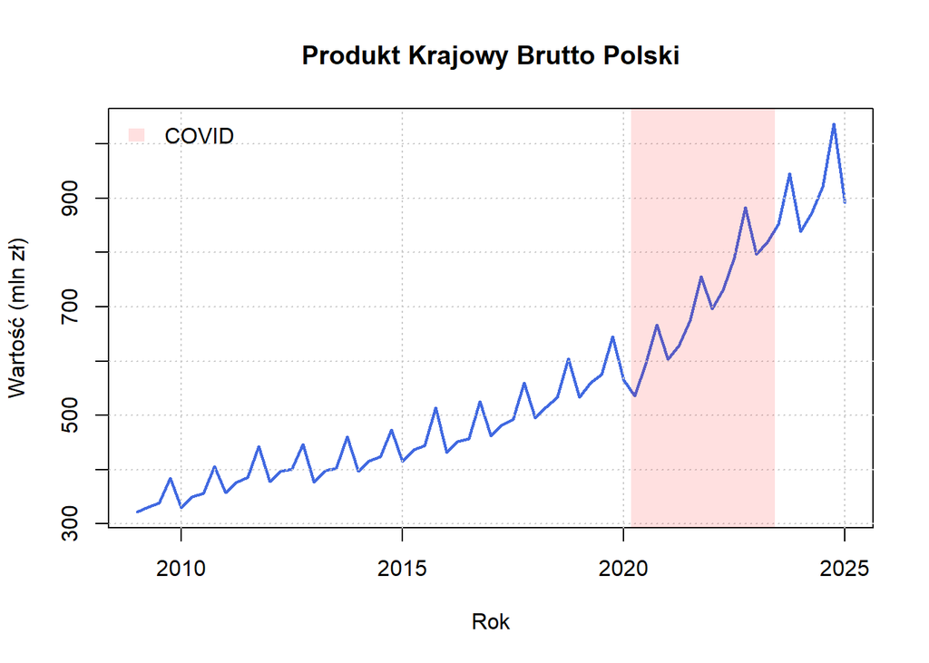

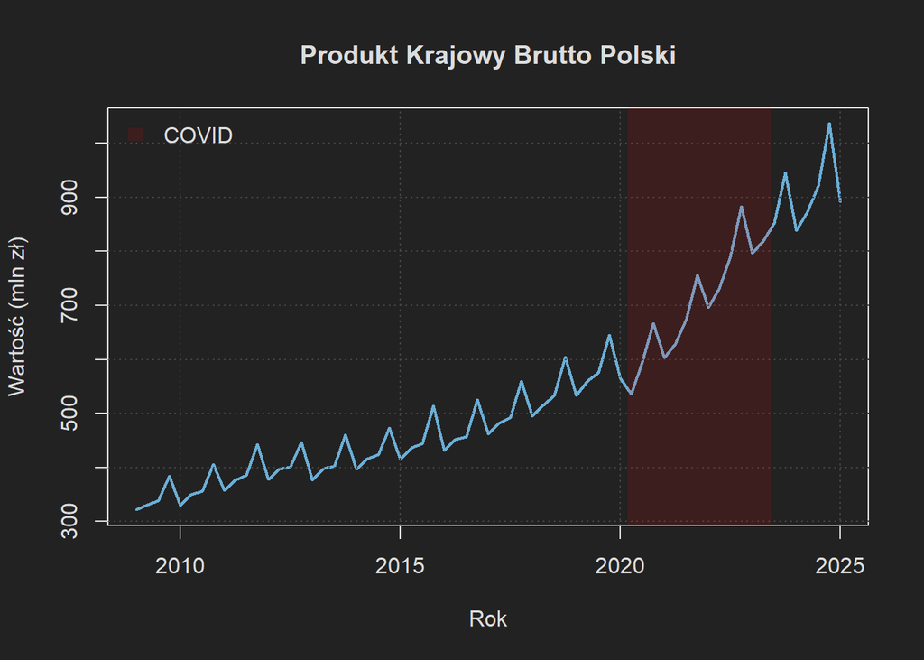

```r
# Autor: Maciej Kuchcik

pkb_raw <- read_excel("makro.xlsx", sheet = "PKB")

rok<-as.numeric(format( min(as.Date(pkb_raw$DATA)), "%Y"))
kwartal<-(as.numeric(format( min(as.Date(pkb_raw$DATA)),"%m")) - 1) %/% 3 + 1

pkb_ts <- ts(as.numeric(as.character(pkb_raw$WARTOŚĆ)),
             frequency = 4, start = c(rok, kwartal))
rysuj_makro_wykres(pkb_ts/1000, "Produkt Krajowy Brutto Polski",
                   "Wartość (mln zł)", FORMAT)
```

**Pobranie danych o inflacji**

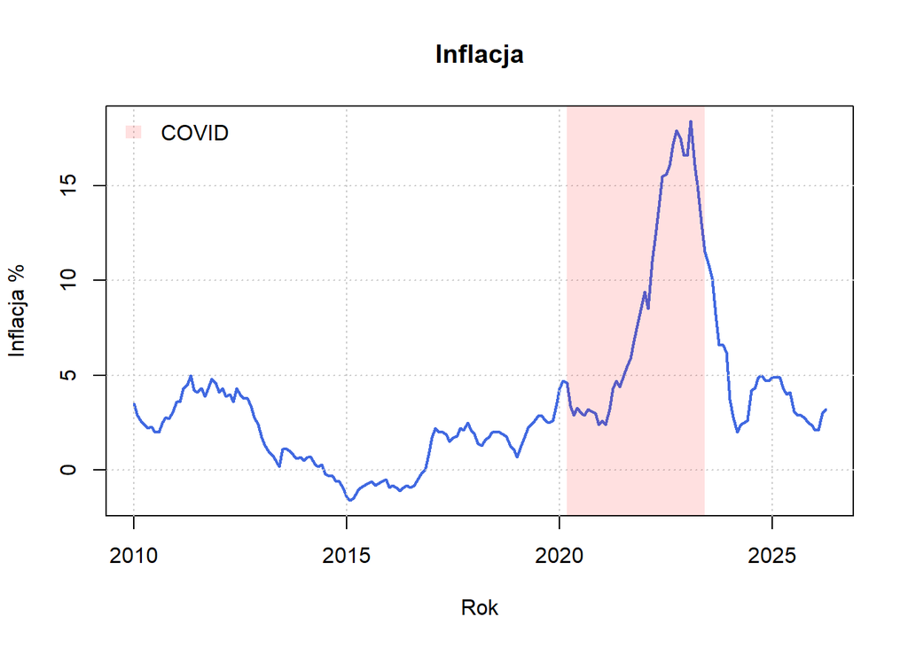

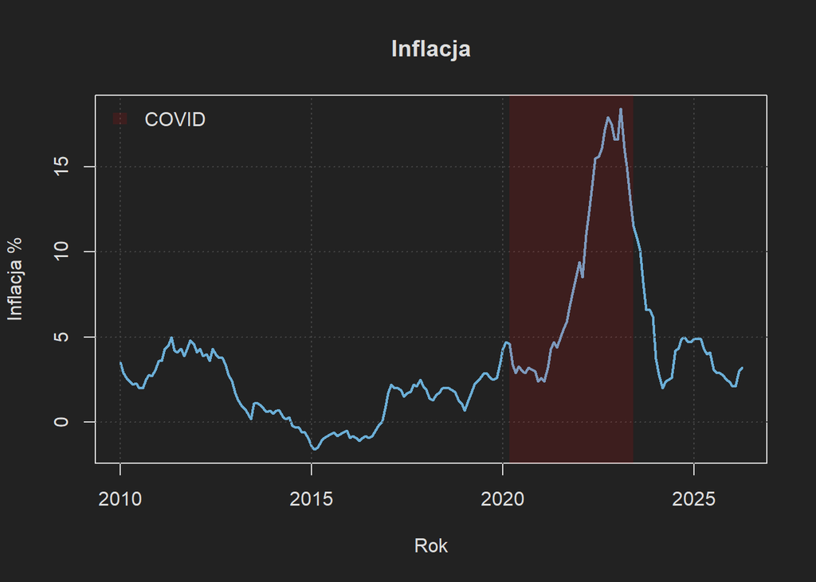

```r
# Autor: Maciej Kuchcik

inflacja_raw <- read_excel("makro.xlsx", sheet = "Inflacja")

rok<-as.numeric(format( min(as.Date(inflacja_raw$DATA)), "%Y"))
miesiac<-as.numeric(format( min(as.Date(inflacja_raw$DATA)),"%m"))

inflacja_ts <- ts(as.numeric(as.character(inflacja_raw$WARTOŚĆ)),
                  frequency = 12, start = c(rok, miesiac))
rysuj_makro_wykres(inflacja_ts - 100, "Inflacja", "Inflacja %", FORMAT)
```

**Pobranie danych o stopie bezrobocia**

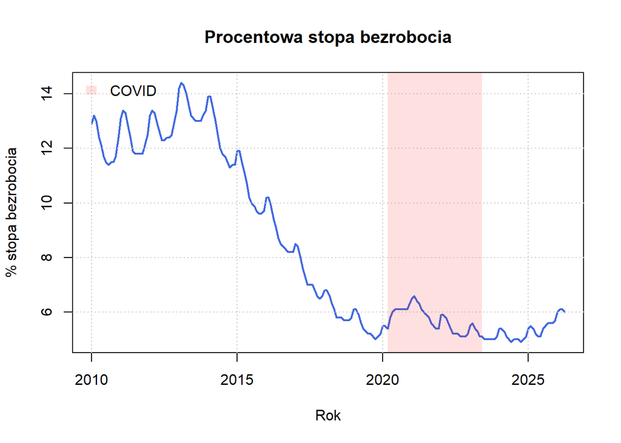

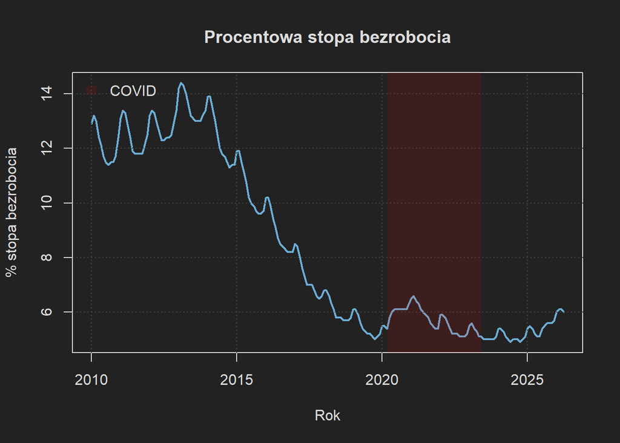

```r
# Autor: Maciej Kuchcik

bezrobocie_raw <- read_excel("makro.xlsx", sheet = "Bezrobocie%")

rok<-as.numeric(format( min(as.Date(bezrobocie_raw$DATA)), "%Y"))
miesiac<-(as.numeric(format( min(as.Date(bezrobocie_raw$DATA)),"%m")))

bezrobocie_ts <- ts(as.numeric(as.character(bezrobocie_raw$WARTOŚĆ)),
                    frequency = 12, start = c(rok, miesiac))
rysuj_makro_wykres(
  bezrobocie_ts, "Procentowa stopa bezrobocia", "% stopa bezrobocia", FORMAT)
```

## Wyznaczenie wspólnego zakresu dat

Należy zbadać, czy wszystkie dane mają tą samą datę początkową i końcą. Jeżeli ich daty się różnią, należy skrócić wszystkie zbiory do największej z daty początkowych oraz najmniejszej z dat końcowych (biorąc pod uwagę różne częstotliwości).

**Analiza zakresów dat**

```r
# Autor: Maciej Kuchcik

zbadaj_daty<-function(data_ts) {
  min_data <- start(data_ts)
  max_data <- end(data_ts)
  freq <- frequency(data_ts)

  freq_name <- switch(as.character(freq),
                      "1"  = "roczne",
                      "4"  = "kwartalne",
                      "12" = "miesięczne",
                      "52" = "tygodniowe",
                      "dzienne")


cat(sprintf(
  "Szereg czasowy '%s' trwa od %d-%02d do %d-%02d o częstotliwości: %s.",
              deparse(substitute(data_ts)),
              min_data[1], min_data[2],
              max_data[1], max_data[2],
              freq_name), "\n")
}

cat(sprintf(
  "Dane giełdowe PZU obejmują zakres od %s do %s o częstotliwości: dzienne.",
            as.character(index(first(pzu_raw))),
            as.character(index(last(pzu_raw)))), "\n")
```

```
Dane giełdowe PZU obejmują zakres od 2010-05-11 do 2026-06-18 o częstotliwości: dzienne.
```

**Analiza zakresów dat**

```r
zbadaj_daty(pkb_ts)
```

```
Szereg czasowy 'pkb_ts' trwa od 2009-01 do 2025-01 o częstotliwości: kwartalne.
```

**Analiza zakresów dat**

```r
zbadaj_daty(bezrobocie_ts)
```

```
Szereg czasowy 'bezrobocie_ts' trwa od 2010-01 do 2026-04 o częstotliwości: miesięczne.
```

**Analiza zakresów dat**

```r
zbadaj_daty(inflacja_ts)
```

```
Szereg czasowy 'inflacja_ts' trwa od 2010-01 do 2026-04 o częstotliwości: miesięczne.
```

Początki: 2010-05-11, 2009-01, 2010-01, 2010-01.

- Najpóźniejszy start to **2010-05-11**. Ze względu na szereg kwartalny, musimy zaokrąglić to do najbliższego pełnego okresu: **2010-07-01** (początek trzeciego kwartału).

- Najwcześniejszy koniec to **2025-01**. Ze względu na to, że to szereg kwartalny, możemy brać daty aż do końca tego kwartału: **2025-03-31**.

**Wyfiltrowanie danych do dat**

```r
# Autor: Maciej Kuchcik

przytnij_dane <- function(data) {
  start <- as.Date("2010-07-01")
  end   <- as.Date("2025-03-31")
  dane_xts <- as.xts(data)
  index(dane_xts) <- as.Date(index(dane_xts))
  window(dane_xts, start = start, end = end)
}

pkb_final        <- przytnij_dane(pkb_ts)
bezrobocie_final <- przytnij_dane(bezrobocie_ts)
inflacja_final   <- przytnij_dane(inflacja_ts)
pzu_final        <- przytnij_dane(pzu_raw)
```

## Synchronizacja danych

**Synchronizacja danych**

```r
# Autor: Maciej Kuchcik

synchronizuj_z_gielda <- function(macro_xts, target_index) {
  # 1. merge z pustym (aby zachowac ilosc)
  # 2. wypelniamy locf, zeby zachowac ostatnia wartosc
  # 3. filtrjemy przez target (dni w gieldzie-nie dziala np w weekendy)
  return(na.locf(merge(macro_xts, xts(order.by = target_index)))[target_index])
}
index <- index(pzu_final)

pkb_daily        <- synchronizuj_z_gielda(pkb_final, index)
bezrobocie_daily <- synchronizuj_z_gielda(bezrobocie_final, index)
inflacja_daily   <- synchronizuj_z_gielda(inflacja_final, index)

c(nrow(pkb_daily), nrow(bezrobocie_daily),
  nrow(inflacja_daily), nrow(pzu_final))
```

```
[1] 3786 3786 3786 3786
```

**Stworzenie wspólnej kolekcji**

```r
# Autor: Maciej Kuchcik

all_data <- merge(pzu_final, pkb_daily, bezrobocie_daily, inflacja_daily)
names(all_data) <- c("PZU.WA.Open", "PZU.WA.High", "PZU.WA.Low",
                     "PZU.WA.Close", "PZU.WA.Volume", "PZU.WA.Adjusted",
                     "PKB", "Bezrobocie","Inflacja")
class(all_data)
```

```
[1] "xts" "zoo"
```

**Stworzenie wspólnej kolekcji**

```r
head(all_data)
```

```
           PZU.WA.Open PZU.WA.High PZU.WA.Low PZU.WA.Close PZU.WA.Volume
2010-07-01       35.00       35.77      34.82        35.60       2284080
2010-07-02       35.28       36.00      35.28        35.40       1717140
2010-07-05       35.42       35.52      35.20        35.21        241000
2010-07-06       35.28       35.86      35.26        35.86        468870
2010-07-07       35.41       35.90      35.35        35.80       2073780
2010-07-08       36.00       36.48      35.60        35.89       4223670
           PZU.WA.Adjusted      PKB Bezrobocie Inflacja
2010-07-01        14.04981 356417.9       11.5      102
2010-07-02        13.97087 356417.9       11.5      102
2010-07-05        13.89589 356417.9       11.5      102
2010-07-06        14.15242 356417.9       11.5      102
2010-07-07        14.12873 356417.9       11.5      102
2010-07-08        14.16426 356417.9       11.5      102
```

## Podział danych na zbiór treningowy i testowy

W analizie szeregów czasowych (VAR, ARIMA) standardem jest podział na próbę **wewnątrzpróbkową** (*in-sample*, treningową) oraz **pozapróbkową** (*out-of-sample*, testową). Wszystkie modele porównujemy uczciwie na tym samym zbiorze testowym.

Dane dzielimy chronologicznie w proporcji **80/20**:

- **Treningowy (80%)** - estymacja modeli (*in-sample*),
- **Testowy (20%)** - ocena jakości predykcji pozapróbkowej (*out-of-sample*).

**Podział danych na 80-20%**

```r
# Autor: Maciej Kuchcik

n <- nrow(all_data)

n_train <- floor(0.80 * n)
n_test  <- n - n_train

all_data_train <- all_data[1:n_train, ]
all_data_test  <- all_data[(n_train + 1):n, ]

cat(sprintf(
  "Liczba obserwacji: %d
    Treningowy (80%%): %d  (%s - %s)
    Testowy    (20%%): %d  (%s - %s)\n",
  n,
  nrow(all_data_train), as.character(index(first(all_data_train))),
    as.character(index(last(all_data_train))),
  nrow(all_data_test),  as.character(index(first(all_data_test))),
    as.character(index(last(all_data_test)))
))
```

```
Liczba obserwacji: 3786
    Treningowy (80%): 3028  (2010-07-01 - 2022-03-18)
    Testowy    (20%): 758  (2022-03-21 - 2025-03-31)
```

# Analiza i predykcja

Ta częśc projektu zostanie pośwęcona ostatecznej predykcji dziennych cen zamknięcia akcji spółki PZU wykorzystujac coraz to bardziej zaawansowane metody, by zweryfikować, które dane i jak najbardziej wpływają na jakoś danych wyjściowych. Zostanie zastosowana taka kolejność:

1. **Model naiwny/bazowy:** $\text{predykcja} = \text{wartość wczorajsza}$. Wykorzystane zostaną tylko dane z cen zamknięcia (jeden wymiar, jedna częstotliwość).
2. **Model ARIMA:** wykorzystana zostanie *autoarima* na cenach zamknięcia (jeden wymiar, jedna częstotliwość).
3. **Model ARIMAX:** rozszerza ARIMA o zmiany PKB, inflacji i stopy bezroboci
4. **Model VAR A:** użyje funkcji *VAR* oraz pełnych danych giełdowych z cenami zamknięcia, wolumenem, cenami minimalnymi i maksymalnymi (kilka wymiarów, jedna częstotliwość).
5. **Model VAR B:** do danych z **VAR A** dołożone zostaną dane makroekonomiczne (kilka wymiarów, jedna częstotliwość).

## Model naiwny

Jak opisano we wstępie, model naiwny (czy też bazowy) będzie zakładał, że
$$\text{predykowana cena} = \text{cena wczorajsza}$$
Będzie to model jednowymiarowy, korzystający tylko z cen zamknięcia i posłuży jako baseline (wartość porównawcza) do predykcji z innych modeli.

**Wykres predykcji i błędów**

```r
# Autor: Maciej Kuchcik

pzu_train <- all_data_train$PZU.WA.Close
pzu_test  <- all_data_test$PZU.WA.Close
##| renderings: [light, dark]
# predykcja naiwna = cena wczorajsza (lag o 1 dzień) na zbiorze testowym
pzu_test_pred <- lag(all_data$PZU.WA.Close, k = 1)[(n_train + 1):n, ]
pzu_test_real <- pzu_test
blad_naiwny <- as.numeric(pzu_test_real) - as.numeric(pzu_test_pred)

metryki_naiwny <- oblicz_metryki(blad_naiwny, pzu_test_real)

wykres_predykcji(index(pzu_test_real),
       as.numeric(pzu_test_real),
       as.numeric(pzu_test_pred),
       blad_naiwny,
       "Model naiwny - predykcja vs rzeczywistość", "naiwna")
```

[interactive chart not shown]

**Wykres predykcji i błędów**

```r
metryki_naiwny
```

```
      MAE      RMSE      MAPE
0.5220052 0.7395874 1.3100040
```

**Metryki** (zbiór testowy, ok. 3 lata: 2022-03 – 2025-03):

- MAE = 0,52 zł - średnio model myli się o ok. 52 grosze,
- RMSE = 0,74 zł - większy od MAE, zdarzają się pojedyncze dni z większymi skokami (RMSE karze mocniej za duże błędy),
- MAPE = 1,31% - procentowo błąd jest bardzo mały. Przy cenie akcji z zakresu ok. 23–59 zł pomyłka o 1.31% to właśnie około pół złotego.

**Wykres:**

Linia błędu oscyluje blisko zera przez większość okresu, co potwierdza, że ceny PZU zmieniają się powoli i model naiwny dobrze to wykorzystuje. Widoczne są pojedyncze wyraźne skoki błędu, a największy z 16 września 2024 (ok. -7.5 zł), kolejny 6 września 2023 (ok. -3.2 zł). Okazuje się, że to były [dni wypłat dywidend](https://strefainwestorow.pl/notowania/spolki/PLPZU0000011/dywidendy) dla tej spółki, czego model nie mógł przewidzieć.

## Model ARIMA i ARIMAX

W tej części porównane zostaną dwa modele szeregu czasowego:

1. **ARIMA** – wykorzystujący wyłącznie wcześniejsze zmiany ceny zamknięcia PZU,
2. **ARIMAX** – rozszerzający ARIMA o zmiany PKB, inflacji i stopy bezrobocia

W obu modelach prognozowana jest logarytmiczna stopa zwrotu ceny zamknięcia.Zastosowanie stóp zwrotu zamiast surowych cen pozwala otrzymać stacjonarny szereg

**Przygotowanie danych dla ARIMA i ARIMAX**

```r
# Autor: Andrzej Szuwald

# Logarytmiczna stopa zwrotu ceny zamknięcia PZU
zwrot_pzu <- diff(log(all_data$PZU.WA.Close))

# Zmiany wskaźników makroekonomicznych
# lag(..., k = 1) oznacza, że wykorzystujemy wartość z poprzedniego okresu sprawozdawczego. Ogranicza to ryzyko wykorzystania informacji,która nie była jeszcze znana w momencie prognozy.

pkb_zmiana_arimax <- lag(diff(log(pkb_final)), k = 1)
inflacja_zmiana_arimax <- lag(diff(inflacja_final), k = 1)
bezrobocie_zmiana_arimax <- lag(diff(bezrobocie_final), k = 1)

# Przypisanie ostatniej dostępnej wartości makro do kolejnych dni giełdowych
daty_gieldowe <- index(pzu_final)

pkb_arimax <- synchronizuj_z_gielda(
  pkb_zmiana_arimax,
  daty_gieldowe
)

inflacja_arimax <- synchronizuj_z_gielda(
  inflacja_zmiana_arimax,
  daty_gieldowe
)

bezrobocie_arimax <- synchronizuj_z_gielda(
  bezrobocie_zmiana_arimax,
  daty_gieldowe
)

# Jeden wspólny zbiór dla obu modeli, by mogły zostać ocenione na tych samych dniach
dane_arima_arimax <- merge(
  zwrot = zwrot_pzu,
  pkb = pkb_arimax,
  inflacja = inflacja_arimax,
  bezrobocie = bezrobocie_arimax
)

colnames(dane_arima_arimax) <- c(
  "zwrot",
  "pkb",
  "inflacja",
  "bezrobocie"
)

dane_arima_arimax <- dane_arima_arimax[
  apply(
    dane_arima_arimax,
    1,
    function(wiersz) all(is.finite(wiersz))
  ),
]

# Podział według tej samej daty granicznej używanej przez pozostałe modele
koniec_train_arima <- end(all_data_train)

dane_arima_train <- dane_arima_arimax[
  index(dane_arima_arimax) <= koniec_train_arima
]

dane_arima_test <- dane_arima_arimax[
  index(dane_arima_arimax) > koniec_train_arima
]

cat(
  "Trening:",
  nrow(dane_arima_train),
  "obserwacji\n"
)
```

```
Trening: 2896 obserwacji
```

**Przygotowanie danych dla ARIMA i ARIMAX**

```r
cat(
  "Test:",
  nrow(dane_arima_test),
  "obserwacji\n"
)
```

```
Test: 758 obserwacji
```

### Standaryzacja zmiennych makroekonomicznych

Przeprowadzamy standaryzacje z uwagi na to, że nasze dane mają różne jednostki i skale

**Standaryzacja zmiennych dla ARIMAX**

```r
# Autor: Andrzej Szuwald

y_train_arima <- as.numeric(dane_arima_train$zwrot)
y_test_arima <- as.numeric(dane_arima_test$zwrot)

xreg_train_raw_arimax <- as.matrix(
  dane_arima_train[, c("pkb", "inflacja", "bezrobocie")]
)

xreg_test_raw_arimax <- as.matrix(
  dane_arima_test[, c("pkb", "inflacja", "bezrobocie")]
)

# Parametry standaryzacji są wyznaczane wyłącznie na treningu.
xreg_srednia_arimax <- colMeans(xreg_train_raw_arimax)
xreg_odchylenie_arimax <- apply(xreg_train_raw_arimax, 2, sd)

# Zabezpieczenie przed dzieleniem przez zero.
xreg_odchylenie_arimax[
  !is.finite(xreg_odchylenie_arimax) |
    xreg_odchylenie_arimax == 0
] <- 1

xreg_train_arimax <- sweep(
  xreg_train_raw_arimax,
  2,
  xreg_srednia_arimax,
  FUN = "-"
)

xreg_train_arimax <- sweep(
  xreg_train_arimax,
  2,
  xreg_odchylenie_arimax,
  FUN = "/"
)

xreg_test_arimax <- sweep(
  xreg_test_raw_arimax,
  2,
  xreg_srednia_arimax,
  FUN = "-"
)

xreg_test_arimax <- sweep(
  xreg_test_arimax,
  2,
  xreg_odchylenie_arimax,
  FUN = "/"
)

colnames(xreg_train_arimax) <- c(
  "pkb",
  "inflacja",
  "bezrobocie"
)

colnames(xreg_test_arimax) <- colnames(xreg_train_arimax)
```

### Test stacjonarności

**Test stacjonarności zwrotów PZU**

```r
# Autor: Andrzej Szuwald

wynik_adf_arima <- suppressWarnings(
  adf.test(y_train_arima)
)

print(wynik_adf_arima)
```

```
    Augmented Dickey-Fuller Test

data:  y_train_arima
Dickey-Fuller = -14.513, Lag order = 14, p-value = 0.01
alternative hypothesis: stationary
```

**Test stacjonarności zwrotów PZU**

```r
if (wynik_adf_arima$p.value < 0.05) {
  cat("Logarytmiczne stopy zwrotu PZU są stacjonarne.\n")
} else {
  cat("Brak podstaw do uznania stóp zwrotu za stacjonarne.\n")
}
```

```
Logarytmiczne stopy zwrotu PZU są stacjonarne.
```

Wynik testu ADF pozwala odrzucić hipotezę o występowaniu pierwiastka jednostkowego, ponieważ wartość p-value jest mniejsza od 0,05. Logarytmiczne stopy zwrotu ceny zamknięcia PZU są zatem stacjonarne i nie wymagają dodatkowego różnicowania

### Model ARIMA

Ponieważ zmienna została już przekształcona do postaci stacjonarnej, ustalamy stopień różnicowania na `d = 0`. Funkcja `auto.arima()` wybiera wartości `p` i `q` na podstawie kryterium AICc

**Wybór modelu ARIMA**

```r
# Autor: Andrzej Szuwald

model_arima <- auto.arima(
  y_train_arima,
  d = 0,
  max.d = 0,
  stationary = TRUE,
  seasonal = FALSE,
  ic = "aicc",
  stepwise = FALSE,
  approximation = FALSE,
  allowmean = TRUE
)

cat("Wybrany model ARIMA:\n")
```

```
Wybrany model ARIMA:
```

**Wybór modelu ARIMA**

```r
print(model_arima)
```

```
Series: y_train_arima
ARIMA(0,0,0) with zero mean

sigma^2 = 0.0002696:  log likelihood = 7791.02
AIC=-15580.03   AICc=-15580.03   BIC=-15574.06
```

**Wybór modelu ARIMA**

```r
cat("\nRząd modelu ARIMA:\n")
```

```
Rząd modelu ARIMA:
```

**Wybór modelu ARIMA**

```r
print(arimaorder(model_arima))
```

```
p d q
0 0 0
```

**Wybór modelu ARIMA**

```r
summary(model_arima)
```

```
Series: y_train_arima
ARIMA(0,0,0) with zero mean

sigma^2 = 0.0002696:  log likelihood = 7791.02
AIC=-15580.03   AICc=-15580.03   BIC=-15574.06

Training set error measures:
                        ME       RMSE        MAE MPE MAPE      MASE        ACF1
Training set -1.135481e-05 0.01642079 0.01175216 100  100 0.6868969 0.006895613
```

### Model ARIMAX

ARIMAX rozszerza model ARIMA o zewnętrzne zmienne objaśniające:

- zmianę PKB,
- zmianę inflacji,
- zmianę stopy bezrobocia.

**Wybór modelu ARIMAX**

```r
# Autor: Andrzej Szuwald

model_arimax <- auto.arima(
  y_train_arima,
  xreg = xreg_train_arimax,
  d = 0,
  max.d = 0,
  stationary = TRUE,
  seasonal = FALSE,
  ic = "aicc",
  stepwise = FALSE,
  approximation = FALSE,
  allowmean = TRUE
)

cat("Wybrany model ARIMAX:\n")
```

```
Wybrany model ARIMAX:
```

**Wybór modelu ARIMAX**

```r
print(model_arimax)
```

```
Series: y_train_arima
Regression with ARIMA(0,0,0) errors

Coefficients:
        pkb  inflacja  bezrobocie
      2e-04    -6e-04      -4e-04
s.e.  4e-04     3e-04       4e-04

sigma^2 = 0.0002695:  log likelihood = 7793.27
AIC=-15578.55   AICc=-15578.53   BIC=-15554.66
```

**Wybór modelu ARIMAX**

```r
cat("\nRząd błędów modelu ARIMAX:\n")
```

```
Rząd błędów modelu ARIMAX:
```

**Wybór modelu ARIMAX**

```r
print(arimaorder(model_arimax))
```

```
p d q
0 0 0
```

**Wybór modelu ARIMAX**

```r
summary(model_arimax)
```

```
Series: y_train_arima
Regression with ARIMA(0,0,0) errors

Coefficients:
        pkb  inflacja  bezrobocie
      2e-04    -6e-04      -4e-04
s.e.  4e-04     3e-04       4e-04

sigma^2 = 0.0002695:  log likelihood = 7793.27
AIC=-15578.55   AICc=-15578.53   BIC=-15554.66

Training set error measures:
                        ME     RMSE        MAE MPE MAPE      MASE        ACF1
Training set -1.135481e-05 0.016408 0.01176794 NaN  Inf 0.6878196 0.005823321
```

### Istotność współczynników ARIMAX

**Istotność współczynników ARIMAX**

```r
# Autor: Andrzej Szuwald

wsp_arimax <- coef(model_arimax)
se_arimax <- sqrt(diag(model_arimax$var.coef))
z_arimax <- wsp_arimax / se_arimax
p_arimax <- 2 * (1 - pnorm(abs(z_arimax)))

tabela_wsp_arimax <- data.frame(
  Zmienna = names(wsp_arimax),
  Wspolczynnik = as.numeric(wsp_arimax),
  Blad_standardowy = as.numeric(se_arimax),
  Statystyka_z = as.numeric(z_arimax),
  p_value = as.numeric(p_arimax),
  Istotna_005 = ifelse(p_arimax < 0.05, "Tak", "Nie")
)

knitr::kable(
  tabela_wsp_arimax,
  digits = 6,
  col.names = c(
    "Zmienna",
    "Współczynnik",
    "Błąd standardowy",
    "Statystyka z",
    "p-value",
    "Istotna przy 0,05"
  ),
  caption = "Ocena istotności współczynników ARIMAX"
)
```

Ocena istotności współczynników ARIMAX

|  | Zmienna | Współczynnik | Błąd standardowy | Statystyka z | p-value | Istotna przy 0,05 |
| --- | --- | --- | --- | --- | --- | --- |
| pkb | pkb | 0.000248 | 0.000384 | 0.647082 | 0.517579 | Nie |
| inflacja | inflacja | -0.000632 | 0.000311 | -2.032320 | 0.042121 | Tak |
| bezrobocie | bezrobocie | -0.000373 | 0.000386 | -0.965466 | 0.334312 | Nie |

### Porównanie AICc modeli

**Porównanie kryteriów informacyjnych**

```r
# Autor: Andrzej Szuwald

tabela_aicc <- data.frame(
  Model = c("ARIMA", "ARIMAX"),
  AIC = c(model_arima$aic, model_arimax$aic),
  AICc = c(model_arima$aicc, model_arimax$aicc),
  BIC = c(model_arima$bic, model_arimax$bic)
)

knitr::kable(
  tabela_aicc,
  digits = 2,
  caption = "Kryteria informacyjne modeli ARIMA i ARIMAX"
)
```

Kryteria informacyjne modeli ARIMA i ARIMAX

| Model | AIC | AICc | BIC |
| --- | --- | --- | --- |
| ARIMA | -15580.03 | -15580.03 | -15574.06 |
| ARIMAX | -15578.55 | -15578.53 | -15554.66 |

### Diagnostyka ARIMA i ARIMAX

**Diagnostyka modelu ARIMA**

```r
# Autor: Andrzej Szuwald
cat("Model_ARIMA")
```

```
Model_ARIMA
```

**Diagnostyka modelu ARIMA**

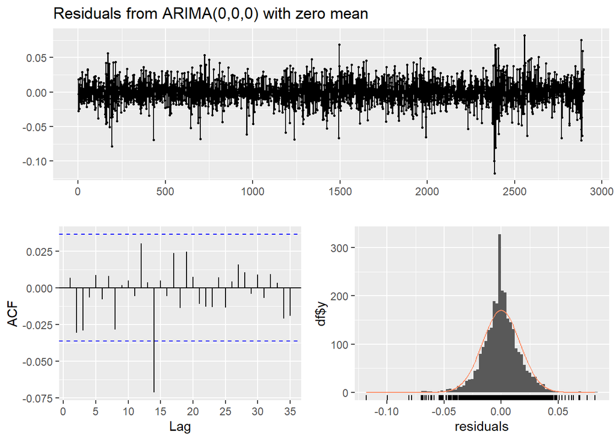

Diagnostyka reszt modelu ARIMA

```
    Ljung-Box test

data:  Residuals from ARIMA(0,0,0) with zero mean
Q* = 8.468, df = 10, p-value = 0.5832

Model df: 0.   Total lags used: 10
```

```r
checkresiduals(model_arima)
```

**Diagnostyka modelu ARIMA**

```r
cat("Model_ARIMAX")
```

```
Model_ARIMAX
```

**Diagnostyka modelu ARIMA**

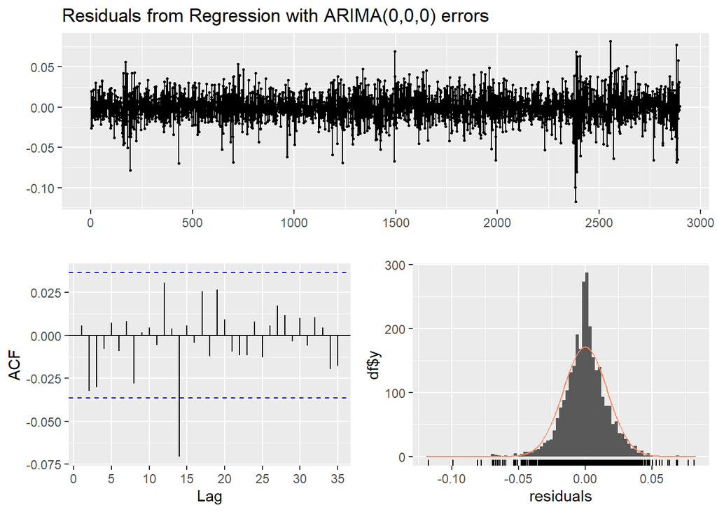

```
    Ljung-Box test

data:  Residuals from Regression with ARIMA(0,0,0) errors
Q* = 8.945, df = 10, p-value = 0.5373

Model df: 0.   Total lags used: 10
```

```r
checkresiduals(model_arimax)
```

### Rekursywna prognoza jednodniowa

by zachować zgodność z modelami VAR, wykonujemy prognozę jednodniową z rozszerzanym oknem. W każdym kroku modele wykorzystują wyłącznie obserwacje dostępne przed prognozowanym dniem

**Rekursywna prognoza ARIMA i ARIMAX**

```r
# Autor: Andrzej Szuwald

# Rzędy wybranych modeli
order_arima <- unname(
  arimaorder(model_arima)[c("p", "d", "q")]
)

order_arimax <- unname(
  arimaorder(model_arimax)[c("p", "d", "q")]
)

# Sprawdzenie, czy modele zawierają średnią
arima_ma_srednia <- (
  "intercept" %in% names(coef(model_arima))
)

arimax_ma_srednia <- (
  "intercept" %in% names(coef(model_arimax))
)

n_test_modeli <- length(y_test_arima)

prognozy_zwrot_arima <- numeric(n_test_modeli)
prognozy_zwrot_arimax <- numeric(n_test_modeli)

for (i in seq_len(n_test_modeli)) {

  if (i == 1) {

  historia_y <- y_train_arima
  historia_x <- xreg_train_arimax

  } else {

    historia_y <- c(
      y_train_arima,
      y_test_arima[seq_len(i - 1)]
    )

    historia_x <- rbind(
      xreg_train_arimax,
      xreg_test_arimax[seq_len(i - 1), , drop = FALSE]
    )
  }

  # ARIMA
  model_tmp_arima <- Arima(
    historia_y,
    order = order_arima,
    include.mean = arima_ma_srednia,
    method = "ML"
  )

  pred_tmp_arima <- forecast(
    model_tmp_arima,
    h = 1
  )

  prognozy_zwrot_arima[i] <- as.numeric(
    pred_tmp_arima$mean[1]
  )

  # ARIMAX
  model_tmp_arimax <- Arima(
    historia_y,
    order = order_arimax,
    xreg = historia_x,
    include.mean = arimax_ma_srednia,
    method = "ML"
  )

  xreg_nastepny <- matrix(
    xreg_test_arimax[i, ],
    nrow = 1
  )

  colnames(xreg_nastepny) <- colnames(xreg_train_arimax)

  pred_tmp_arimax <- forecast(
    model_tmp_arimax,
    h = 1,
    xreg = xreg_nastepny
  )

  prognozy_zwrot_arimax[i] <- as.numeric(
    pred_tmp_arimax$mean[1]
  )
}
```

### Odtworzenie poziomu cen

Modele ARIMA i ARIMAX prognozują logarytmiczne stopy zwrotu. Prognozowaną cenę otrzymujemy ze wzoru:

$$\widehat{P_t} = P_{t-1}\exp(\widehat{r_t}),$$

gdzie:

- $P_{t-1}$ oznacza cenę z poprzedniego dnia,
- $\widehat{r_t}$ oznacza prognozowaną logarytmiczną stopę zwrotu.

**Przeliczenie prognoz na ceny zamknięcia**

```r
# Autor: Andrzej Szuwald

daty_test_arima <- index(dane_arima_test)

cena_real_arima <- as.numeric(
  all_data$PZU.WA.Close[daty_test_arima]
)

cena_poprzednia_arima <- as.numeric(
  lag(all_data$PZU.WA.Close, k = 1)[daty_test_arima]
)

cena_pred_arima <- cena_poprzednia_arima *
  exp(prognozy_zwrot_arima)

cena_pred_arimax <- cena_poprzednia_arima *
  exp(prognozy_zwrot_arimax)

blad_arima <- cena_real_arima - cena_pred_arima
blad_arimax <- cena_real_arima - cena_pred_arimax
```

### Metryki ARIMA i ARIMAX

**Metryki ARIMA i ARIMAX**

```r
# Autor: Andrzej Szuwald

metryki_arima <- oblicz_metryki(
  blad_arima,
  cena_real_arima
)

metryki_arimax <- oblicz_metryki(
  blad_arimax,
  cena_real_arima
)

cat("Metryki ARIMA:\n")
```

```
Metryki ARIMA:
```

**Metryki ARIMA i ARIMAX**

```r
print(metryki_arima)
```

```
      MAE      RMSE      MAPE
0.5220052 0.7395874 1.3100040
```

**Metryki ARIMA i ARIMAX**

```r
cat("\nMetryki ARIMAX:\n")
```

```
Metryki ARIMAX:
```

**Metryki ARIMA i ARIMAX**

```r
print(metryki_arimax)
```

```
      MAE      RMSE      MAPE
0.5222863 0.7388490 1.3100433
```

#### Interpretacja metryk

ARIMA uzyskała wyniki identyczne jak model naiwny, ponieważ wybrana postać ARIMA(0,0,0) prognozuje zerową stopę zwrotu

Spadek RMSE jest mniejszy niż jedna dziesiąta grosza i nie ma praktycznego znaczenia. ARIMAX nie wykazał zatem wyraźnej przewagi prognostycznej nad ARIMA

### Wykres ARIMA

**Wykres prognozy ARIMA**

```r
# Autor: Andrzej Szuwald

wykres_predykcji(
  daty_test_arima,
  cena_real_arima,
  cena_pred_arima,
  blad_arima,
  "ARIMA - predykcja vs rzeczywistość",
  "ARIMA"
)
```

[interactive chart not shown]

ARIMA - prognoza ceny PZU na zbiorze testowym

### Wykres ARIMAX

**Wykres prognozy ARIMAX**

```r
# Autor: Andrzej Szuwald

wykres_predykcji(
  daty_test_arima,
  cena_real_arima,
  cena_pred_arimax,
  blad_arimax,
  "ARIMAX - predykcja vs rzeczywistość",
  "ARIMAX"
)
```

[interactive chart not shown]

ARIMAX - prognoza ceny PZU na zbiorze testowym

#### Interpretacja wykresów ARIMA I ARIMAX

Prognozy ARIMA i ARIMAX przebiegają bardzo podobnie i są zbliżone do prognozy naiwnej. Największe błędy występują w dniach gwałtownych zmian ceny, których nie można było przewidzieć na podstawie spokojnie zmieniających się danych makroekonomicznych. Wykresy potwierdzają niewielką różnicę widoczną w metrykach

### Porównanie ARIMA i ARIMAX z naiwnym

**Tabela porównawcza ARIMA i ARIMAX**

```r
# Autor: Andrzej Szuwald

tabela_naiwny_arima_arimax <- data.frame(
  Model = c(
    "Naiwny",
    "ARIMA",
    "ARIMAX"
  ),
  MAE = unname(c(
    metryki_naiwny["MAE"],
    metryki_arima["MAE"],
    metryki_arimax["MAE"]
  )),
  RMSE = unname(c(
    metryki_naiwny["RMSE"],
    metryki_arima["RMSE"],
    metryki_arimax["RMSE"]
  )),
  MAPE = unname(c(
    metryki_naiwny["MAPE"],
    metryki_arima["MAPE"],
    metryki_arimax["MAPE"]
  ))
)

knitr::kable(
  tabela_naiwny_arima_arimax,
  digits = 4,
  col.names = c(
    "Model",
    "MAE (zł)",
    "RMSE (zł)",
    "MAPE (%)"
  ),
  caption = "Porównanie modelu naiwnego, ARIMA i ARIMAX"
)
```

Porównanie modelu naiwnego, ARIMA i ARIMAX

| Model | MAE (zł) | RMSE (zł) | MAPE (%) |
| --- | --- | --- | --- |
| Naiwny | 0.5220 | 0.7396 | 1.31 |
| ARIMA | 0.5220 | 0.7396 | 1.31 |
| ARIMAX | 0.5223 | 0.7388 | 1.31 |

#### Wniosek z porównania ARIMA i ARIMAX

Porównanie nie wykazało praktycznie istotnej przewagi ARIMAX nad ARIMA. Dodanie zmian PKB, inflacji i bezrobocia spowodowało minimalne obniżenie RMSE, ale jednocześnie nieznacznie zwiększyło MAE, natomiast MAPE pozostało bez zmian. Różnice są zbyt małe, aby uznać, że dane makroekonomiczne poprawiają jednodniową prognozę ceny zamknięcia PZU

#### Wniosek z porównania ARIMA I ARIMAX Z Naiwnym

Model ARIMA uzyskał praktycznie takie same wyniki co model naiwny, więc nie uzyskuje przewagi nad naiwnym. Wynika to z tego, że model prognozuje zerową stopę zwrotu, dlatego po odtworzeniu poziomu ceny jego prognoza jest spójna z poprzednią ceną zamknięcia

Model ARIMAX nieznacznie różni się od naiwnego, jednak minimalnie. W przypadku różnic to są one poniżej grosza, więc można nawet uznawać go za równego pozostałym z uwagi na to, że różnice są minimalne, co też potwierdzą znikomy wpływ dodania PKB, inflacji i bezrobocia

## Model VAR A

### Testy stacjonarności

**Testy stacjonarności**

```r
# Autor: Maciej Kuchcik

czy_stacjonarny <- function(series, nazwa = deparse(substitute(series))) {
  test_wynik <- suppressWarnings(adf.test(series))
  p <- test_wynik$p.value
  p_formatted <- if (p <= 0.01) "< 0.01" else formatC(p, digits = 4, format = "f")

  if (p < 0.05) {
    cat(sprintf("%s jest STACJONARNY (%s).\n", nazwa, p_formatted))
    return(1)
  } else {
    cat(sprintf("%s NIE jest stacjonarny (%s).\n", nazwa, p_formatted))
    return(0)
  }
}

sprawdz_wszystkie <- function(data) {
  wyniki <- sapply(names(data), function(col) {
    czy_stacjonarny(na.omit(data[, col]), nazwa = col)
  })
  return(wyniki)
}

sprawdz_wszystkie(all_data_train)
```

```
PZU.WA.Open NIE jest stacjonarny (0.3911).
PZU.WA.High NIE jest stacjonarny (0.4023).
PZU.WA.Low NIE jest stacjonarny (0.3936).
PZU.WA.Close NIE jest stacjonarny (0.4062).
PZU.WA.Volume jest STACJONARNY (< 0.01).
PZU.WA.Adjusted NIE jest stacjonarny (0.3707).
PKB jest STACJONARNY (< 0.01).
Bezrobocie NIE jest stacjonarny (0.6221).
Inflacja NIE jest stacjonarny (0.9900).
```

```
    PZU.WA.Open     PZU.WA.High      PZU.WA.Low    PZU.WA.Close   PZU.WA.Volume
              0               0               0               0               1
PZU.WA.Adjusted             PKB      Bezrobocie        Inflacja
              0               1               0               0
```

### Tworzenie modelu

Do modelu VAR(A) trafiają wyłącznie dane giełdowe (kilka wymiarów, jedna częstotliwość). Ceny są niestacjonarne, więc każdą serię sprowadzamy do logarytmicznych stóp zwrotu (`diff(log(...))`). Transformacje liczymy na pełnym szeregu, a dopiero potem dzielimy na trening/test, wtedy nie gubimy zwrotu na granicy podziału.

**Budowa zmiennych stacjonarnych dla VAR A**

```r
# Autor: Maciej Kuchcik

ret_close <-diff(log(all_data$PZU.WA.Close))
ret_high <-diff(log(all_data$PZU.WA.High))
ret_low <-diff(log(all_data$PZU.WA.Low))
ret_vol <- diff(log(all_data$PZU.WA.Volume + 1))

dane_var <- merge(
  zamkniecia = ret_close,
  najwyzsze= ret_high,
  najnizsze= ret_low,
  wolumen =ret_vol
)

colnames(dane_var) <- c("zamkniecia", "najwyzsze", "najnizsze", "wolumen")

dane_var <- dane_var[apply(dane_var, 1, function(r) all(is.finite(r))), ]

# podzial 80/20
koniec_train <- end(all_data_train)
var_A <- dane_var[index(dane_var) <= koniec_train]
var_A_test <- dane_var[index(dane_var) >  koniec_train]

stacjonarnosc_var_A <- sprawdz_wszystkie(var_A)
```

```
zamkniecia jest STACJONARNY (< 0.01).
najwyzsze jest STACJONARNY (< 0.01).
najnizsze jest STACJONARNY (< 0.01).
wolumen jest STACJONARNY (< 0.01).
```

**Budowa zmiennych stacjonarnych dla VAR A**

```r
if (!all(stacjonarnosc_var_A == 1)) {
  warning("Uwaga: nie wszystkie zmienne VAR(A) wyszły stacjonarne w teście ADF.")
}
all(stacjonarnosc_var_A == 1)
```

```
[1] TRUE
```

### Predykcja

Rząd opóźnień $p$ dobieramy kryterium AIC.

**Dobór rzędu i estymacja VAR A**

```r
# Autor: Maciej Kuchcik

var_A_fit <- estymuj_var(var_A)
```

```
Optymalny rząd VAR (AIC): 10
```

**Dobór rzędu i estymacja VAR A**

```r
model_var_A <- var_A_fit$model
p_opt       <- var_A_fit$p_opt
summary(model_var_A)
```

```
VAR Estimation Results:
=========================
Endogenous variables: zamkniecia, najwyzsze, najnizsze, wolumen
Deterministic variables: const
Sample size: 3017
Log Likelihood: 22276.931
Roots of the characteristic polynomial:
0.8216 0.8216 0.7958 0.7958 0.7869 0.7869 0.7845 0.7845 0.7774 0.7774 0.775 0.775 0.7683 0.7683 0.7663 0.7663 0.7652 0.7652 0.7523 0.7523 0.7495 0.7495 0.7463 0.7463 0.7446 0.7446 0.7403 0.7403 0.7342 0.7342 0.7299 0.7238 0.7238 0.7225 0.7225 0.6478 0.6478 0.5726 0.5726 0.3382
Call:
VAR(y = dane, p = p_opt, type = "const")


Estimation results for equation zamkniecia:
===========================================
zamkniecia = zamkniecia.l1 + najwyzsze.l1 + najnizsze.l1 + wolumen.l1 + zamkniecia.l2 + najwyzsze.l2 + najnizsze.l2 + wolumen.l2 + zamkniecia.l3 + najwyzsze.l3 + najnizsze.l3 + wolumen.l3 + zamkniecia.l4 + najwyzsze.l4 + najnizsze.l4 + wolumen.l4 + zamkniecia.l5 + najwyzsze.l5 + najnizsze.l5 + wolum…

                 Estimate Std. Error t value Pr(>|t|)
zamkniecia.l1  -9.793e-02  3.729e-02  -2.626 0.008689 **
najwyzsze.l1    9.143e-02  4.434e-02   2.062 0.039288 *
najnizsze.l1    7.909e-02  3.955e-02   2.000 0.045640 *
wolumen.l1     -2.650e-04  1.242e-04  -2.134 0.032963 *
zamkniecia.l2  -2.685e-01  6.366e-02  -4.218 2.54e-05 ***
najwyzsze.l2    2.236e-01  5.787e-02   3.863 0.000114 ***
najnizsze.l2    7.577e-02  4.977e-02   1.522 0.128025
wolumen.l2     -2.090e-04  1.518e-04  -1.377 0.168653
zamkniecia.l3  -3.246e-01  7.795e-02  -4.165 3.21e-05 ***
najwyzsze.l3    2.319e-01  6.511e-02   3.561 0.000375 ***
najnizsze.l3    8.138e-02  5.589e-02   1.456 0.145478
wolumen.l3     -2.053e-04  1.694e-04  -1.211 0.225831
zamkniecia.l4  -2.733e-01  8.546e-02  -3.198 0.001398 **
najwyzsze.l4    2.066e-01  6.964e-02   2.967 0.003028 **
najnizsze.l4    3.631e-02  5.883e-02   0.617 0.537174
wolumen.l4     -2.620e-04  1.811e-04  -1.447 0.147990
zamkniecia.l5  -2.217e-01  8.923e-02  -2.484 0.013040 *
najwyzsze.l5    1.252e-01  7.202e-02   1.739 0.082197 .
najnizsze.l5    1.033e-01  6.024e-02   1.715 0.086408 .
wolumen.l5     -2.129e-04  1.852e-04  -1.150 0.250340
zamkniecia.l6  -2.141e-01  8.963e-02  -2.388 0.016987 *
najwyzsze.l6    7.956e-02  7.131e-02   1.116 0.264673
najnizsze.l6    1.126e-01  5.984e-02   1.882 0.059911 .
```

[output cut: 191 more lines]

```


Covariance matrix of residuals:
           zamkniecia najwyzsze  najnizsze    wolumen
zamkniecia  2.642e-04 1.497e-04  1.642e-04  6.489e-06
najwyzsze   1.497e-04 1.350e-04  9.528e-05  5.616e-03
najnizsze   1.642e-04 9.528e-05  1.652e-04 -6.260e-03
wolumen     6.489e-06 5.616e-03 -6.260e-03  7.036e+00

Correlation matrix of residuals:
           zamkniecia najwyzsze najnizsze    wolumen
zamkniecia  1.0000000    0.7928    0.7859  0.0001505
najwyzsze   0.7928142    1.0000    0.6380  0.1822207
najnizsze   0.7859351    0.6380    1.0000 -0.1836039
wolumen     0.0001505    0.1822   -0.1836  1.0000000
```

Prognozę pozapróbkową budujemy rekursywnie, a model estymujemy na zbiorze treningowym i krok po kroku dokładamy kolejne zrealizowane obserwacje testowe, za każdym razem prognozując jeden dzień naprzód (okno rozszerzane).

**Rekursywna prognoza VAR A na zbiorze testowym**

```r
# Autor: Maciej Kuchcik

prognozy <- prognoza_var_rekursywna(as.data.frame(var_A), var_A_test, p_opt)
```

Model prognozuje log-stopę zwrotu. Dzięki temu metryki są w złotówkach i wprost porównywalne z modelem naiwnym, liczone na dokładnie tych samych datach.

**Metryki VAR A i naiwnego**

```r
# Autor: Maciej Kuchcik

daty_test <- index(var_A_test)

cena_real<-as.numeric(all_data$PZU.WA.Close[daty_test])
cena_prev<-as.numeric(lag(all_data$PZU.WA.Close, k = 1)[daty_test])

cena_pred_var <- cena_prev * exp(prognozy)
e_var <- cena_real - cena_pred_var

metryki_var_A <- oblicz_metryki(e_var, cena_real)

cat("Metryki VAR na zbiorze testowym (zł):\n")
```

```
Metryki VAR na zbiorze testowym (zł):
```

**Metryki VAR A i naiwnego**

```r
print(metryki_var_A)
```

```
      MAE      RMSE      MAPE
0.5225836 0.7396256 1.3120153
```

**Metryki VAR A i naiwnego**

```r
cat("\nMetryki modelu naiwnego na zbiorze testowym (zł):\n")
```

```
Metryki modelu naiwnego na zbiorze testowym (zł):
```

**Metryki VAR A i naiwnego**

```r
print(metryki_naiwny)
```

```
      MAE      RMSE      MAPE
0.5220052 0.7395874 1.3100040
```

**Wykres predykcji VAR A**

```r
# Autor: Maciej Kuchcik

wykres_predykcji(daty_test, cena_real, cena_pred_var, e_var,
                 "VAR A: predykcja vs rzeczywistość", "VAR A")
```

[interactive chart not shown]

**Wykres predykcji VAR A**

```r
##| renderings: [light, dark]
```

**Wynik:** VAR na samych danych giełdowych praktycznie nie różni się od modelu naiwnego (MAE: 0,52 zł, RMSE: 0,74 zł, MAPE: 1,31% są prawie identycznie). Dzienne stopy zwrotu PZU są w praktyce nieprzewidywalne na podstawie własnej historii oraz cen max/min i wolumenu, a prognozowany zwrot oscyluje wokół zera, więc predykcja ceny sprowadza się do **ceny wczorajszej**.

## Model VAR B

Model VAR B rozszerza VAR A o trzy zmienne makroekonomiczne: **PKB** (kwartalne), **inflację** i **stopę bezrobocia** (miesięczne). Pojawia się problem różnych częstotliwości. Dane giełdowe są dzienne, a makro kwartalne/miesięczne.

Do tego celu użyta została funkcja schodkowa (`na.locf`), a nie interpolacja liniowa, ponieważ lepiej odwzorowuje to informacje giełdowe (PKB nie jest znane codziennie.)

### Tworzenie modelu

**Synchronizacja zmiennych schodkowo**

```r
# Autor: Maciej Kuchcik

pkb_d_daily <- synchronizuj_z_gielda(diff(log(pkb_final)), index)
inflacja_d_daily <- synchronizuj_z_gielda(diff(inflacja_final), index)
bezrob_d_daily<- synchronizuj_z_gielda(diff(bezrobocie_final),index)


dane_var_B <- merge(
  zamkniecia = diff(log(all_data$PZU.WA.Close)),
  najwyzsze = diff(log(all_data$PZU.WA.High)),
  najnizsze = diff(log(all_data$PZU.WA.Low)),
  wolumen = diff(log(all_data$PZU.WA.Volume + 1)),
  pkb = pkb_d_daily,
  bezrob= bezrob_d_daily,
  inflacja =inflacja_d_daily
)

colnames(dane_var_B) <- c("zamkniecia", "najwyzsze",
                    "najnizsze", "wolumen",
                    "pkb", "bezrob", "inflacja")

dane_var_B <- dane_var_B[apply(dane_var_B, 1,
                         function(r) all(is.finite(r))), ]

# podział 80/20
koniec_train <- end(all_data_train)
var_B <- dane_var_B[index(dane_var_B) <= koniec_train]
var_B_test<- dane_var_B[index(dane_var_B) >  koniec_train]

stacjonarnosc_var_B <- sprawdz_wszystkie(var_B)
```

```
zamkniecia jest STACJONARNY (< 0.01).
najwyzsze jest STACJONARNY (< 0.01).
najnizsze jest STACJONARNY (< 0.01).
wolumen jest STACJONARNY (< 0.01).
pkb jest STACJONARNY (< 0.01).
bezrob jest STACJONARNY (< 0.01).
inflacja jest STACJONARNY (< 0.01).
```

**Synchronizacja zmiennych schodkowo**

```r
if (!all(stacjonarnosc_var_B == 1)) {
  warning("NIE WSZYSTKIE zmienne stacjonarne w ADF.")
}
all(stacjonarnosc_var_B == 1)
```

```
[1] TRUE
```

### Predykcja

**Dobór rzędu i estymacja VAR B**

```r
# Autor: Maciej Kuchcik

var_B_fit <- estymuj_var(var_B)
```

```
Optymalny rząd VAR (AIC): 10
```

**Dobór rzędu i estymacja VAR B**

```r
model_var_B <- var_B_fit$model
p_opt_B  <- var_B_fit$p_opt
summary(model_var_B)
```

```
VAR Estimation Results:
=========================
Endogenous variables: zamkniecia, najwyzsze, najnizsze, wolumen, pkb, bezrob, inflacja
Deterministic variables: const
Sample size: 2952
Log Likelihood: 36353.278
Roots of the characteristic polynomial:
0.985 0.985 0.945 0.8178 0.8178 0.8145 0.8145 0.7979 0.7979 0.7938 0.7938 0.7931 0.7931 0.7925 0.7925 0.7827 0.7827 0.7807 0.7785 0.7785 0.7716 0.7716 0.7685 0.7685 0.7685 0.7685 0.7671 0.7671 0.7646 0.7646 0.7644 0.7644 0.7572 0.7572 0.754 0.754 0.742 0.742 0.7402 0.7402 0.7313 0.7313 0.7239 0.7239…
Call:
VAR(y = dane, p = p_opt, type = "const")


Estimation results for equation zamkniecia:
===========================================
zamkniecia = zamkniecia.l1 + najwyzsze.l1 + najnizsze.l1 + wolumen.l1 + pkb.l1 + bezrob.l1 + inflacja.l1 + zamkniecia.l2 + najwyzsze.l2 + najnizsze.l2 + wolumen.l2 + pkb.l2 + bezrob.l2 + inflacja.l2 + zamkniecia.l3 + najwyzsze.l3 + najnizsze.l3 + wolumen.l3 + pkb.l3 + bezrob.l3 + inflacja.l3 + zamkn…

                 Estimate Std. Error t value Pr(>|t|)
zamkniecia.l1  -0.0868660  0.0379234  -2.291 0.022061 *
najwyzsze.l1    0.0888195  0.0450684   1.971 0.048845 *
najnizsze.l1    0.0660255  0.0402682   1.640 0.101188
wolumen.l1     -0.0002477  0.0001265  -1.959 0.050262 .
pkb.l1          0.0118120  0.0157707   0.749 0.453928
bezrob.l1       0.0058620  0.0068468   0.856 0.391977
inflacja.l1    -0.0009971  0.0025732  -0.387 0.698428
zamkniecia.l2  -0.2585351  0.0649717  -3.979 7.09e-05 ***
najwyzsze.l2    0.2158319  0.0589359   3.662 0.000255 ***
najnizsze.l2    0.0696017  0.0507285   1.372 0.170157
wolumen.l2     -0.0001893  0.0001554  -1.218 0.223232
pkb.l2         -0.0020301  0.0218324  -0.093 0.925920
bezrob.l2      -0.0179181  0.0095236  -1.881 0.060013 .
inflacja.l2     0.0043313  0.0036160   1.198 0.231086
zamkniecia.l3  -0.3108753  0.0796404  -3.903 9.70e-05 ***
najwyzsze.l3    0.2279614  0.0664754   3.429 0.000614 ***
najnizsze.l3    0.0716777  0.0570045   1.257 0.208709
wolumen.l3     -0.0001842  0.0001736  -1.061 0.288638
pkb.l3         -0.0163913  0.0218515  -0.750 0.453243
bezrob.l3       0.0093607  0.0095297   0.982 0.326052
inflacja.l3    -0.0033697  0.0036156  -0.932 0.351423
zamkniecia.l4  -0.2513113  0.0874118  -2.875 0.004070 **
najwyzsze.l4    0.1923335  0.0710811   2.706 0.006854 **
```

[output cut: 588 more lines]

```
zamkniecia   1.000000  0.792055  0.786485  0.001830  0.012871 -0.005399
najwyzsze    0.792055  1.000000  0.638543  0.183593  0.003653 -0.024947
najnizsze    0.786485  0.638543  1.000000 -0.180164  0.007704  0.027887
wolumen      0.001830  0.183593 -0.180164  1.000000  0.013074 -0.062386
pkb          0.012871  0.003653  0.007704  0.013074  1.000000 -0.341151
bezrob      -0.005399 -0.024947  0.027887 -0.062386 -0.341151  1.000000
inflacja    -0.017087  0.017796  0.005068 -0.001091  0.021166 -0.055683
            inflacja
zamkniecia -0.017087
najwyzsze   0.017796
najnizsze   0.005068
wolumen    -0.001091
pkb         0.021166
bezrob     -0.055683
inflacja    1.000000
```

**Rekursywna prognoza VAR na zbiorze testowym**

```r
# Autor: Maciej Kuchcik

prognozy_B <- prognoza_var_rekursywna(as.data.frame(var_B), var_B_test, p_opt_B)
```

**Metryki VAR B w zł (porównywalne z A i naiwnym)**

```r
# Autor: Maciej Kuchcik

daty_test_B <- index(var_B_test)

cena_real_B<- as.numeric(all_data$PZU.WA.Close[daty_test_B])
cena_prev_B<- as.numeric(lag(all_data$PZU.WA.Close, k = 1)[daty_test_B])
cena_pred_var_B <- cena_prev_B * exp(prognozy_B)

e_var_B <- cena_real_B - cena_pred_var_B

metryki_var_B <-oblicz_metryki(e_var_B, cena_real_B)

cat("Metryki VAR na zbiorze testowym (zł):\n")
```

```
Metryki VAR na zbiorze testowym (zł):
```

**Metryki VAR B w zł (porównywalne z A i naiwnym)**

```r
metryki_var_B
```

```
      MAE      RMSE      MAPE
0.5284334 0.7450519 1.3263705
```

**Wykres predykcji VAR B**

```r
# Autor: Maciej Kuchcik

wykres_predykcji(daty_test_B, cena_real_B, cena_pred_var_B, e_var_B,
                 "VAR B: predykcja vs rzeczywistość", "VAR B")
```

[interactive chart not shown]

**Wynik:** dołożenie danych makroekonomicznych **nie poprawia** prognozy, a VAR B wypada nawet gorzej niż modelu naiwnego.

| Model | MAE (zł) | RMSE (zł) | MAPE |
| --- | --- | --- | --- |
| Naiwny | 0.522 | 0.740 | 1.31% |
| VAR A: giełda | 0.523 | 0.740 | 1.31% |
| VAR B: giełda + makro | 0.528 | 0.745 | 1.33% |

# Wyniki

Powód jest spójny z wcześniejszą diagnozą: dane makro zmieniają się wolno (kwartalnie/miesięcznie) i po synchronizacji schodkowej są w obrębie okresu stałe, nie niosą więc informacji o *dziennych* ruchach kursu. Dołożenie trzech zmiennych i dodatkowych parametrów (przy $p=10$) lekko pogarsza wynik pozapróbkowy (delikatne przeuczenie). Wniosek: na częstotliwości dziennej makro nie pomaga przewidywać kursu PZU, różnice między modelami mieszczą się w granicach szumu, a najprostszy model naiwny pozostaje twardym benchmarkiem. Po informację makro o wyższej wartości predykcyjnej należałoby sięgnąć po model jawnie mieszanej częstotliwości (np. MIDAS) zamiast wtłaczać miesięczne/kwartalne dane do dziennego VAR-a.

## Tabela z wynikami końcowymi

**Kod**

```r
tabela_wyniki_koncowe <- data.frame(
  Model = c(
    "Naiwny",
    "ARIMA",
    "ARIMAX",
    "VAR A",
    "VAR B"
  ),
  MAE = unname(c(
    metryki_naiwny["MAE"],
    metryki_arima["MAE"],
    metryki_arimax["MAE"],
    metryki_var_A["MAE"],
    metryki_var_B["MAE"]
  )),
  RMSE = unname(c(
    metryki_naiwny["RMSE"],
    metryki_arima["RMSE"],
    metryki_arimax["RMSE"],
    metryki_var_A["RMSE"],
    metryki_var_B["RMSE"]
  )),
  MAPE = unname(c(
    metryki_naiwny["MAPE"],
    metryki_arima["MAPE"],
    metryki_arimax["MAPE"],
    metryki_var_A["MAPE"],
    metryki_var_B["MAPE"]
  ))
)

knitr::kable(
  tabela_wyniki_koncowe,
  digits = 4,
  col.names = c(
    "Model",
    "MAE (zł)",
    "RMSE (zł)",
    "MAPE (%)"
  ),
  caption = "Końcowe porównanie wszystkich modeli"
)
```

Końcowe porównanie wszystkich modeli

| Model | MAE (zł) | RMSE (zł) | MAPE (%) |
| --- | --- | --- | --- |
| Naiwny | 0.5220 | 0.7396 | 1.3100 |
| ARIMA | 0.5220 | 0.7396 | 1.3100 |
| ARIMAX | 0.5223 | 0.7388 | 1.3100 |
| VAR A | 0.5226 | 0.7396 | 1.3120 |
| VAR B | 0.5284 | 0.7451 | 1.3264 |

# Wnioski i podsumowanie

Celem projektu było sprawdzenie, czy dane giełdowe oraz informacje o PKB, inflacji i bezrobociu pomagają przewidywać dzienną cenę zamknięcia akcji PZU

Model naiwny osiągnął MAE 0,5220 zł, RMSE 0,7396 zł i MAPE 1,31%. Model ARIMA uzyskał identyczne wyniki, ponieważ wybrano postać ARIMA(0,0,0), która w praktyce prognozuje cenę z poprzedniego dnia

ARIMAX, uwzględniający dane makroekonomiczne, osiągnął minimalnie niższy RMSE, ale nieznacznie wyższy MAE. Różnice były bardzo małe, dlatego nie można uznać ARIMAX za wyraźnie lepszy. Spośród zmiennych makroekonomicznych tylko inflacja okazała się statystycznie istotna, ale nie przełożyło się to na zauważalną poprawę prognozy

Podobne wyniki uzyskano dla modeli VAR. VAR A był zbliżony do modelu naiwnego, natomiast VAR B po dodaniu danych makroekonomicznych osiągnął nieco gorsze wyniki

Można więc stwierdzić, że w przypadku jednodniowego prognozowania ceny PZU bardziej rozbudowane modele nie były wyraźnie lepsze od modelu naiwnego. Dane makroekonomiczne mogą mieć większe znaczenie w analizie miesięcznej lub kwartalnej, ponieważ zmieniają się znacznie wolniej niż dzienne ceny akcji